# Pokémon Attack Stat GLM Analysis

Comprehensive Generalized Linear Model Analysis for Attack Power

Jan Tychtl

2025-12-13

# Introduction

## Research Objective

This analysis focuses on **Attack** as the primary target variable. We aim to:

1. **Understand what drives Attack stats** — Which factors (generation, type, rarity, other stats) best explain variation in Attack?
2. **Quantify generation effects** — Is there evidence of power creep specifically in Attack values?
3. **Build predictive models** — Develop GLMs that accurately predict Attack from available features
4. **Compare model specifications** — Evaluate Gaussian vs Gamma GLMs, different link functions, and control variable sets

# 1. Setup and Data Loading

```r
# Core packages
library(tidyverse)
library(ggplot2)
library(gridExtra)

# Statistical modeling
library(car)          # VIF, ANOVA
library(MASS)         # Robust regression
library(lmtest)       # Breusch-Pagan test
library(broom)        # Tidy model outputs
library(glmnet)       # LASSO regularization

# Specialized tests
library(moments)      # Skewness and kurtosis
library(DescTools)    # Jonckheere-Terpstra test

# Visualization
library(corrplot)     # Correlation plots
library(scales)       # Scale functions for plots
```

```r
# Load data using relative paths from the Rmd file location
pokemon <- read.csv("../data/data_clean.csv")
cat("Dataset loaded:", nrow(pokemon), "Pokémon\n")
```

```
## Dataset loaded: 1024 Pokémon
```

```r
# Type name lookup tables (from pokemon.csv original names)
primary_type_lookup <- c(
  "0" = "Grass", "1" = "Fire", "2" = "Water", "3" = "Bug",
  "4" = "Normal", "5" = "Poison", "6" = "Electric", "7" = "Ground",
  "8" = "Fairy", "9" = "Fighting", "10" = "Psychic", "11" = "Rock",
  "12" = "Ghost", "13" = "Ice", "14" = "Dragon", "15" = "Dark",
  "16" = "Steel", "17" = "Flying"
)

secondary_type_lookup <- c(
  "0" = "Poison", "1" = "(None)", "2" = "Flying", "3" = "Dark",
  "4" = "Electric", "5" = "Ice", "6" = "Ground", "7" = "Fairy",
  "8" = "Grass", "9" = "Fighting", "10" = "Psychic", "11" = "Steel",
  "12" = "Fire", "13" = "Rock", "14" = "Water", "15" = "Dragon",
  "16" = "Ghost", "17" = "Bug", "18" = "Normal"
)

# Add readable type names BEFORE converting to factors
pokemon <- pokemon %>%
  mutate(
    type_name = primary_type_lookup[as.character(class_primary)],
    type_name_secondary = secondary_type_lookup[as.character(class_secondary)]
  )

# Convert factors
pokemon <- pokemon %>%
  mutate(
    gen = as.factor(gen),
    rarity = as.factor(rarity),
    class_primary = as.factor(class_primary),
    class_secondary = as.factor(class_secondary),
    has_mega_evolution = as.factor(has_mega_evolution),
    has_gigantamax = as.factor(has_gigantamax)
  )

# Define rarity levels (0 = normal, 1 = sublegendary, 2 = legendary, 3 = mythical)
levels(pokemon$rarity) <- c("Normal", "SubLegendary", "Legendary", "Mythical")

# Create derived features
pokemon <- pokemon %>%
  mutate(
    total_stats = hp + attack + defense + sp_attack + sp_defense + speed,
    physical_power = attack + defense,
    special_power = sp_attack + sp_defense,
    offensive_power = attack + sp_attack,
    defensive_power = defense + sp_defense,
    gen_numeric = as.numeric(as.character(gen))
  )

# ═══════════════════════════════════════════════════════════════════
# DEFINE PREDICTOR SETS (used throughout the analysis)
# ═══════════════════════════════════════════════════════════════════

# All predictors for full model (excluding attack which is the response)
all_predictors <- c(
  # Generation (main predictor of interest)
  "gen",
  # Combat stats
  "hp", "defense", "sp_attack", "sp_defense", "speed",
  # Pokémon characteristics
  "capture_rate", "rarity", "height_m", "weight_kg", "base_egg_steps",
  "num_abilities", "evo_length", "has_mega_evolution", "has_gigantamax",
  # Types
  "class_primary", "class_secondary",
  # Demographics
  "percent_male","percent_female",
  # Popularity
  "votes_first", "votes_top_6",
  # Type effectiveness (18 types)
  "against_normal", "against_fire", "against_water", "against_electric",
  "against_grass", "against_ice", "against_fighting", "against_poison",
  "against_ground", "against_flying", "against_psychict", "against_bug",
  "against_rock", "against_ghost", "against_dragon", "against_dark",
  "against_steel", "against_fairy"
)

# Predictors without generation (for null model)
predictors_no_gen <- setdiff(all_predictors, "gen")

# Create formula helper function
make_formula <- function(response, predictors) {
  as.formula(paste(response, "~", paste(predictors, collapse = " + ")))
}

# Display predictor count
cat("Total predictors:", length(all_predictors), "\n")
```

```
## Total predictors: 39
```

```r
cat("Dataset size:", nrow(pokemon), "Pokémon\n")
```

```
## Dataset size: 1024 Pokémon
```

# 2. Exploratory Analysis of Attack

## 2.1 Attack Distribution

```r
# Basic statistics
attack_stats <- data.frame(
  Statistic = c("Mean", "Median", "SD", "Min", "Max", "Skewness", "Kurtosis"),
  Value = c(
    round(mean(pokemon$attack), 2),
    round(median(pokemon$attack), 2),
    round(sd(pokemon$attack), 2),
    min(pokemon$attack),
    max(pokemon$attack),
    round(skewness(pokemon$attack), 3),
    round(kurtosis(pokemon$attack), 3)
  )
)

print(attack_stats, row.names = FALSE)
```

```
##  Statistic   Value
##       Mean  77.510
##     Median  75.000
##         SD  29.820
##        Min   5.000
##        Max 181.000
##   Skewness   0.281
##   Kurtosis   2.559
```

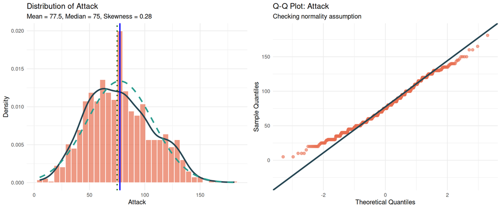

```r
# Histogram with density overlay
p1 <- ggplot(pokemon, aes(x = attack)) +
  geom_histogram(aes(y = after_stat(density)), bins = 35,
                 fill = "#E76F51", alpha = 0.7, color = "white") +
  geom_density(linewidth = 1.2, color = "#264653") +
  stat_function(fun = dnorm,
                args = list(mean = mean(pokemon$attack), sd = sd(pokemon$attack)),
                linewidth = 1.2, color = "#2A9D8F", linetype = "dashed") +
  geom_vline(xintercept = mean(pokemon$attack), color = "blue", linewidth = 1) +
  geom_vline(xintercept = median(pokemon$attack), color = "darkgreen",
             linewidth = 1, linetype = "dotted") +
  labs(title = "Distribution of Attack",
       subtitle = paste0("Mean = ", round(mean(pokemon$attack), 1),
                        ", Median = ", round(median(pokemon$attack), 1),
                        ", Skewness = ", round(skewness(pokemon$attack), 2)),
       x = "Attack", y = "Density") +
  theme_minimal()

# Q-Q plot
p2 <- ggplot(pokemon, aes(sample = attack)) +
  stat_qq(color = "#E76F51", alpha = 0.6, size = 2) +
  stat_qq_line(color = "#264653", linewidth = 1.2) +
  labs(title = "Q-Q Plot: Attack",
       subtitle = "Checking normality assumption",
       x = "Theoretical Quantiles", y = "Sample Quantiles") +
  theme_minimal()

grid.arrange(p1, p2, ncol = 2)
```

```r
# Shapiro-Wilk normality test
shapiro_result <- shapiro.test(pokemon$attack)

data.frame(
  Statistic = c("W", "p-value", "Skewness"),
  Value = c(round(shapiro_result$statistic, 4),
            format.pval(shapiro_result$p.value, digits = 4),
            round(skewness(pokemon$attack), 2))
)
```

```
##   Statistic     Value
## 1         W    0.9874
## 2   p-value 1.024e-07
## 3  Skewness      0.28
```

## 2.2 Attack by Generation

```r
# Summary statistics by generation
gen_summary <- pokemon %>%
  group_by(gen) %>%
  summarise(
    n = n(),
    mean_attack = mean(attack),
    median_attack = median(attack),
    sd_attack = sd(attack),
    min_attack = min(attack),
    max_attack = max(attack),
    se = sd(attack) / sqrt(n())
  ) %>%
  mutate(across(where(is.numeric) & !matches("^n$"), ~round(., 2)))

print(gen_summary, n = Inf)
```

```
## # A tibble: 9 × 8
##   gen       n mean_attack median_attack sd_attack min_attack max_attack    se
##   <fct> <int>       <dbl>         <dbl>     <dbl>      <dbl>      <dbl> <dbl>
## 1 1       151        72.9          70        26.8          5        134  2.18
## 2 2       100        68.3          67.5      28.4         10        134  2.84
## 3 3       135        73.1          70        30.4         15        160  2.61
## 4 4       107        80.2          80        30.9          5        165  2.99
## 5 5       156        81.0          77.5      29.4         25        150  2.35
## 6 6        72        72.5          69        25.6         22        131  3.01
## 7 7        88        84.8          76.5      32.9         20        181  3.5
## 8 8        95        82.9          85        31.3         20        145  3.21
## 9 9       120        82.4          79.5      29.3         30        145  2.68
```

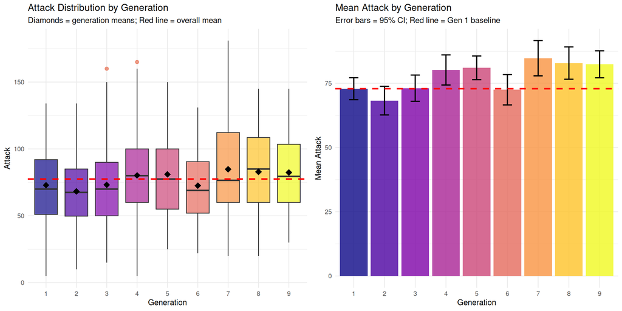

```r
# Boxplot with means
p_box <- ggplot(pokemon, aes(x = gen, y = attack, fill = gen)) +
  geom_boxplot(alpha = 0.7, outlier.color = "#E76F51", outlier.size = 2) +
  stat_summary(fun = mean, geom = "point", shape = 18, size = 4, color = "black") +
  geom_hline(yintercept = mean(pokemon$attack), linetype = "dashed",
             color = "red", linewidth = 1) +
  scale_fill_viridis_d(option = "plasma") +
  labs(title = "Attack Distribution by Generation",
       subtitle = "Diamonds = generation means; Red line = overall mean",
       x = "Generation", y = "Attack") +
  theme_minimal() +
  theme(legend.position = "none")

# Mean plot with error bars
p_means <- ggplot(gen_summary, aes(x = gen, y = mean_attack, fill = gen)) +
  geom_bar(stat = "identity", alpha = 0.8) +
  geom_errorbar(aes(ymin = mean_attack - 1.96*se, ymax = mean_attack + 1.96*se),
                width = 0.3, linewidth = 0.8) +
  geom_hline(yintercept = gen_summary$mean_attack[1], linetype = "dashed",
             color = "red", linewidth = 1) +
  scale_fill_viridis_d(option = "plasma") +
  labs(title = "Mean Attack by Generation",
       subtitle = "Error bars = 95% CI; Red line = Gen 1 baseline",
       x = "Generation", y = "Mean Attack") +
  theme_minimal() +
  theme(legend.position = "none")

grid.arrange(p_box, p_means, ncol = 2)
```

## 2.3 Attack by Rarity

```r
# Summary by rarity
rarity_summary <- pokemon %>%
  group_by(rarity) %>%
  summarise(
    n = n(),
    mean_attack = round(mean(attack), 2),
    sd_attack = round(sd(attack), 2),
    se = round(sd(attack) / sqrt(n()), 2)
  )

print(rarity_summary)
```

```
## # A tibble: 4 × 5
##   rarity           n mean_attack sd_attack    se
##   <fct>        <int>       <dbl>     <dbl> <dbl>
## 1 Normal         934        74.9      28.8  0.94
## 2 SubLegendary    49       103.       26.5  3.78
## 3 Legendary       21       113.       33.0  7.19
## 4 Mythical        20       101.       19.6  4.38
```

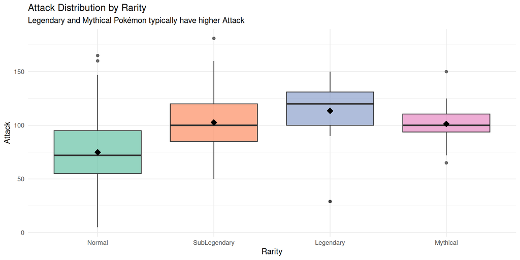

```r
ggplot(pokemon, aes(x = rarity, y = attack, fill = rarity)) +
  geom_boxplot(alpha = 0.7) +
  stat_summary(fun = mean, geom = "point", shape = 18, size = 4, color = "black") +
  scale_fill_brewer(palette = "Set2") +
  labs(title = "Attack Distribution by Rarity",
       subtitle = "Legendary and Mythical Pokémon typically have higher Attack",
       x = "Rarity", y = "Attack") +
  theme_minimal() +
  theme(legend.position = "none")
```

## 2.4 Available Variables Overview

```r
# List all available columns
all_vars <- data.frame(
  Variable = names(pokemon),
  Class = sapply(pokemon, class),
  NonNA = sapply(pokemon, function(x) sum(!is.na(x))),
  Example = sapply(pokemon, function(x) paste0(head(x, 2), collapse = ", "))
)
print(all_vars, row.names = FALSE)
```

```
##             Variable     Class NonNA            Example
##                  gen    factor  1024               1, 1
##         english_name character  1024 Bulbasaur, Ivysaur
##         percent_male   numeric  1024       88.14, 88.14
##       percent_female   numeric  1024       11.86, 11.86
##             height_m   numeric  1024             0.7, 1
##            weight_kg   numeric  1024            6.9, 13
##         capture_rate   numeric  1024             45, 45
##       base_egg_steps   numeric  1024         5120, 5120
##                   hp   numeric  1024             45, 60
##               attack   numeric  1024             49, 62
##              defense   numeric  1024             49, 63
##            sp_attack   numeric  1024             65, 80
##           sp_defense   numeric  1024             65, 80
##                speed   numeric  1024             45, 60
##       against_normal   numeric  1024               1, 1
##         against_fire   numeric  1024               2, 2
##        against_water   numeric  1024           0.5, 0.5
##     against_electric   numeric  1024           0.5, 0.5
##        against_grass   numeric  1024         0.25, 0.25
##          against_ice   numeric  1024               2, 2
##     against_fighting   numeric  1024           0.5, 0.5
##       against_poison   numeric  1024               1, 1
##       against_ground   numeric  1024               1, 1
##       against_flying   numeric  1024               2, 2
##     against_psychict   numeric  1024               2, 2
##          against_bug   numeric  1024               1, 1
##         against_rock   numeric  1024               1, 1
##        against_ghost   numeric  1024               1, 1
##       against_dragon   numeric  1024               1, 1
##         against_dark   numeric  1024               1, 1
##        against_steel   numeric  1024               1, 1
##        against_fairy   numeric  1024           0.5, 0.5
##          votes_first   numeric  1024              57, 2
##          votes_top_6   numeric  1024            147, 25
##        num_abilities   numeric  1024               2, 2
##           evo_length   numeric  1024               5, 5
##   has_mega_evolution    factor  1024               0, 0
##       has_gigantamax    factor  1024               0, 0
##               rarity    factor  1024     Normal, Normal
##        class_primary    factor  1024               0, 0
##      class_secondary    factor  1024               0, 0
##            type_name character  1024       Grass, Grass
##  type_name_secondary character  1024     Poison, Poison
##          total_stats   numeric  1024           318, 405
##       physical_power   numeric  1024            98, 125
##        special_power   numeric  1024           130, 160
##      offensive_power   numeric  1024           114, 142
##      defensive_power   numeric  1024           114, 143
##          gen_numeric   numeric  1024               1, 1
```

## 2.5 Attack by Type (Primary and Secondary)

```r
# Secondary type distribution
secondary_summary <- pokemon %>%
  group_by(class_secondary) %>%
  summarise(
    n = n(),
    mean_attack = round(mean(attack), 1)
  ) %>%
  arrange(desc(mean_attack))

print(secondary_summary, n = Inf)
```

```
## # A tibble: 19 × 3
##    class_secondary     n mean_attack
##    <fct>           <int>       <dbl>
##  1 9                  34       107
##  2 3                  30        95
##  3 11                 29        94.1
##  4 5                  22        92
##  5 13                 16        89.8
##  6 15                 33        88.4
##  7 16                 30        87.7
##  8 4                  11        86.5
##  9 6                  38        81.1
## 10 8                  26        79.1
## 11 2                 100        76.4
## 12 12                 18        75.9
## 13 10                 44        74.3
## 14 1                 471        73.1
## 15 17                  9        72.2
## 16 18                 13        70.6
## 17 14                 20        70.4
## 18 0                  44        69.1
## 19 7                  36        64.8
```

## 2.6 Attack by Primary Type

```r
# Summary by primary type (using readable names)
type_summary_eda <- pokemon %>%
  group_by(type_name) %>%
  summarise(
    n = n(),
    mean_attack = round(mean(attack), 1),
    sd_attack = round(sd(attack), 1),
    median_attack = median(attack)
  ) %>%
  arrange(desc(mean_attack))

print(type_summary_eda, n = Inf)
```

```
## # A tibble: 18 × 5
##    type_name     n mean_attack sd_attack median_attack
##    <chr>     <int>       <dbl>     <dbl>         <dbl>
##  1 Fighting     40       103        27.5         105
##  2 Dragon       37        99        29.9          95
##  3 Ground       40        93.4      29.4          95
##  4 Dark         45        88        26.6          88
##  5 Steel        36        88        25            85
##  6 Rock         58        86.5      32.5          82.5
##  7 Fire         66        82.6      25.6          79.5
##  8 Flying        9        79.9      29.4          85
##  9 Poison       42        75.5      19.9          74
## 10 Ice          31        74.4      29.5          69
## 11 Grass       103        74.3      29            69
## 12 Normal      117        74.1      28.5          75
## 13 Electric     59        73        26            73
## 14 Water       134        72.3      25.3          70
## 15 Ghost        35        68.6      25.9          65
## 16 Bug          83        67.6      33.3          62
## 17 Fairy        29        67.2      31            60
## 18 Psychic      60        63        32.2          55
```

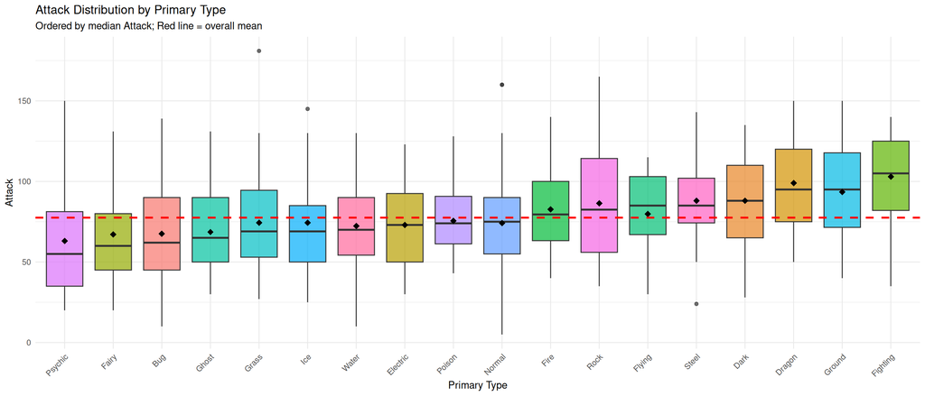

```r
# Boxplot by type
ggplot(pokemon, aes(x = reorder(type_name, attack, FUN = median),
                    y = attack, fill = type_name)) +
  geom_boxplot(alpha = 0.7) +
  stat_summary(fun = mean, geom = "point", shape = 18, size = 3, color = "black") +
  geom_hline(yintercept = mean(pokemon$attack), linetype = "dashed",
             color = "red", linewidth = 1) +
  labs(title = "Attack Distribution by Primary Type",
       subtitle = "Ordered by median Attack; Red line = overall mean",
       x = "Primary Type", y = "Attack") +
  theme_minimal() +
  theme(legend.position = "none",
        axis.text.x = element_text(angle = 45, hjust = 1))
```

# 3. GLM Prerequisites for Attack Models

To use Generalized Linear Models correctly, we must determine:

1. What **TYPE** of variables are we modeling?
2. What **DISTRIBUTION** does the response follow?
3. How does **VARIANCE** relate to the **MEAN**?
4. What **LINK FUNCTION** is appropriate?

## 3.1 Variable Types

```r
# Response variable
response_info <- data.frame(
  Aspect = c("Variable", "Type", "Nature", "Range", "Bounded"),
  Value = c("Attack", "Numeric (continuous)", "Combat statistic",
            paste0(min(pokemon$attack), " - ", max(pokemon$attack)),
            "Yes (positive integers)")
)
cat("═══ RESPONSE VARIABLE ═══\n")
```

```
## ═══ RESPONSE VARIABLE ═══
```

```r
print(response_info, row.names = FALSE)
```

```
##    Aspect                   Value
##  Variable                  Attack
##      Type    Numeric (continuous)
##    Nature        Combat statistic
##     Range                 5 - 181
##   Bounded Yes (positive integers)
```

```r
# All predictor variables organized by category
cat("\n═══ PREDICTOR VARIABLES ═══\n")
```

```
##
## ═══ PREDICTOR VARIABLES ═══
```

```r
cat("\n--- Main Predictor (Generation) ---\n")
```

```
##
## --- Main Predictor (Generation) ---
```

```r
gen_info <- data.frame(
  Variable = "gen",
  Type = "Categorical (factor)",
  Range_Levels = "9 levels (1-9)",
  Description = "Generation introduced"
)
print(gen_info, row.names = FALSE)
```

```
##  Variable                 Type   Range_Levels           Description
##       gen Categorical (factor) 9 levels (1-9) Generation introduced
```

```r
cat("\n--- Combat Stats ---\n")
```

```
##
## --- Combat Stats ---
```

```r
combat_stats <- data.frame(
  Variable = c("hp", "defense", "sp_attack", "sp_defense", "speed"),
  Type = rep("Continuous", 5),
  Range = c(
    paste0(min(pokemon$hp), "-", max(pokemon$hp)),
    paste0(min(pokemon$defense), "-", max(pokemon$defense)),
    paste0(min(pokemon$sp_attack), "-", max(pokemon$sp_attack)),
    paste0(min(pokemon$sp_defense), "-", max(pokemon$sp_defense)),
    paste0(min(pokemon$speed), "-", max(pokemon$speed))
  )
)
print(combat_stats, row.names = FALSE)
```

```
##    Variable       Type  Range
##          hp Continuous  1-255
##     defense Continuous  5-230
##   sp_attack Continuous 10-173
##  sp_defense Continuous 20-230
##       speed Continuous  5-200
```

```r
cat("\n--- Pokémon Characteristics ---\n")
```

```
##
## --- Pokémon Characteristics ---
```

```r
char_vars <- data.frame(
  Variable = c("capture_rate", "height_m", "weight_kg", "base_egg_steps",
               "num_abilities", "evo_length", "percent_male"),
  Type = rep("Continuous", 7),
  Range = c(
    paste0(min(pokemon$capture_rate), "-", max(pokemon$capture_rate)),
    paste0(round(min(pokemon$height_m, na.rm=T), 1), "-", round(max(pokemon$height_m, na.rm=T), 1)),
    paste0(round(min(pokemon$weight_kg, na.rm=T), 1), "-", round(max(pokemon$weight_kg, na.rm=T), 1)),
    paste0(min(pokemon$base_egg_steps, na.rm=T), "-", max(pokemon$base_egg_steps, na.rm=T)),
    paste0(min(pokemon$num_abilities, na.rm=T), "-", max(pokemon$num_abilities, na.rm=T)),
    paste0(min(pokemon$evo_length, na.rm=T), "-", max(pokemon$evo_length, na.rm=T)),
    paste0(min(pokemon$percent_male, na.rm=T), "-", max(pokemon$percent_male, na.rm=T))
  )
)
print(char_vars, row.names = FALSE)
```

```
##        Variable       Type     Range
##    capture_rate Continuous     3-255
##        height_m Continuous    0.1-20
##       weight_kg Continuous 0.1-999.9
##  base_egg_steps Continuous 640-30720
##   num_abilities Continuous       1-3
##      evo_length Continuous       0-7
##    percent_male Continuous     0-100
```

```r
cat("\n--- Categorical Variables ---\n")
```

```
##
## --- Categorical Variables ---
```

```r
cat_vars <- data.frame(
  Variable = c("rarity", "class_primary", "class_secondary",
               "has_mega_evolution", "has_gigantamax"),
  Type = rep("Categorical (factor)", 5),
  Levels = c(
    paste0(length(unique(pokemon$rarity)), " levels"),
    paste0(length(unique(pokemon$class_primary)), " types"),
    paste0(length(unique(pokemon$class_secondary)), " types"),
    "2 levels (0/1)",
    "2 levels (0/1)"
  )
)
print(cat_vars, row.names = FALSE)
```

```
##            Variable                 Type         Levels
##              rarity Categorical (factor)       4 levels
##       class_primary Categorical (factor)       18 types
##     class_secondary Categorical (factor)       19 types
##  has_mega_evolution Categorical (factor) 2 levels (0/1)
##      has_gigantamax Categorical (factor) 2 levels (0/1)
```

```r
cat("\n--- Popularity (Reddit Survey) ---\n")
```

```
##
## --- Popularity (Reddit Survey) ---
```

```r
pop_vars <- data.frame(
  Variable = c("votes_first", "votes_top_6"),
  Type = rep("Continuous", 2),
  Range = c(
    paste0(min(pokemon$votes_first, na.rm=T), "-", max(pokemon$votes_first, na.rm=T)),
    paste0(min(pokemon$votes_top_6, na.rm=T), "-", max(pokemon$votes_top_6, na.rm=T))
  )
)
print(pop_vars, row.names = FALSE)
```

```
##     Variable       Type Range
##  votes_first Continuous  0-69
##  votes_top_6 Continuous 0-248
```

```r
cat("\n--- Type Effectiveness (18 variables) ---\n")
```

```
##
## --- Type Effectiveness (18 variables) ---
```

```r
against_example <- data.frame(
  Variables = "against_normal, against_fire, ... against_fairy",
  Type = "Continuous",
  Range = "0.25 - 4.0 (damage multiplier)",
  Count = "18 variables"
)
print(against_example, row.names = FALSE)
```

```
##                                        Variables       Type
##  against_normal, against_fire, ... against_fairy Continuous
##                           Range        Count
##  0.25 - 4.0 (damage multiplier) 18 variables
```

```r
cat("\n═══ TOTAL PREDICTORS:", length(all_predictors), "═══\n")
```

```
##
## ═══ TOTAL PREDICTORS: 39 ═══
```

**Variable Summary:**

[output not shown]

## 3.2 Distribution of Response Variable

The distribution analysis from Section 2.1 shows:

- **Skewness:** 0.28 (slight positive skew, within acceptable range |skew| < 1)
- **Shapiro-Wilk:** Rejects normality, but with n = 1024, test is overly sensitive
- **Visual assessment:** Approximately normal with slight right tail

```r
dist_assessment <- data.frame(
  Criterion = c("Skewness", "Kurtosis", "Visual (Q-Q)", "Recommendation"),
  Finding = c(
    paste0(round(skewness(pokemon$attack), 2), " (acceptable: |skew| < 1)"),
    paste0(round(kurtosis(pokemon$attack), 2), " (normal = 3)"),
    "Minor deviation in tails only",
    "Gaussian GLM appropriate; Gamma GLM as robustness check"
  )
)
print(dist_assessment, row.names = FALSE)
```

```
##       Criterion                                                 Finding
##        Skewness                           0.28 (acceptable: |skew| < 1)
##        Kurtosis                                       2.56 (normal = 3)
##    Visual (Q-Q)                           Minor deviation in tails only
##  Recommendation Gaussian GLM appropriate; Gamma GLM as robustness check
```

**Conclusion:** Attack is **approximately normally distributed**. A **Gaussian (Normal) distribution** is appropriate for the primary model. We use **Gamma distribution** as a robustness check since Attack is strictly positive.

## 3.3 Variance-Mean Relationship

For GLM family selection, we examine how variance relates to mean:

- **Gaussian (Normal):** Variance is constant (doesn’t depend on mean)
- **Poisson:** Variance equals mean
- **Gamma:** Variance proportional to mean²

```r
# Fit simple model to check residual variance
model_simple <- lm(attack ~ gen, data = pokemon)

# Variance by generation
var_by_gen <- pokemon %>%
  mutate(residuals = residuals(model_simple)) %>%
  group_by(gen) %>%
  summarise(
    n = n(),
    mean_attack = mean(attack),
    var_residuals = var(residuals),
    sd_residuals = sd(residuals)
  )

# Print table
var_by_gen_display <- var_by_gen
var_by_gen_display[, -1] <- round(var_by_gen_display[, -1], 2)
print(var_by_gen_display)
```

```
## # A tibble: 9 × 5
##   gen       n mean_attack var_residuals sd_residuals
##   <fct> <dbl>       <dbl>         <dbl>        <dbl>
## 1 1       151        72.9          716.         26.8
## 2 2       100        68.3          808.         28.4
## 3 3       135        73.1          923.         30.4
## 4 4       107        80.2          954.         30.9
## 5 5       156        81.0          862.         29.4
## 6 6        72        72.5          653.         25.6
## 7 7        88        84.8         1081.         32.9
## 8 8        95        82.9          977.         31.3
## 9 9       120        82.4          860.         29.3
```

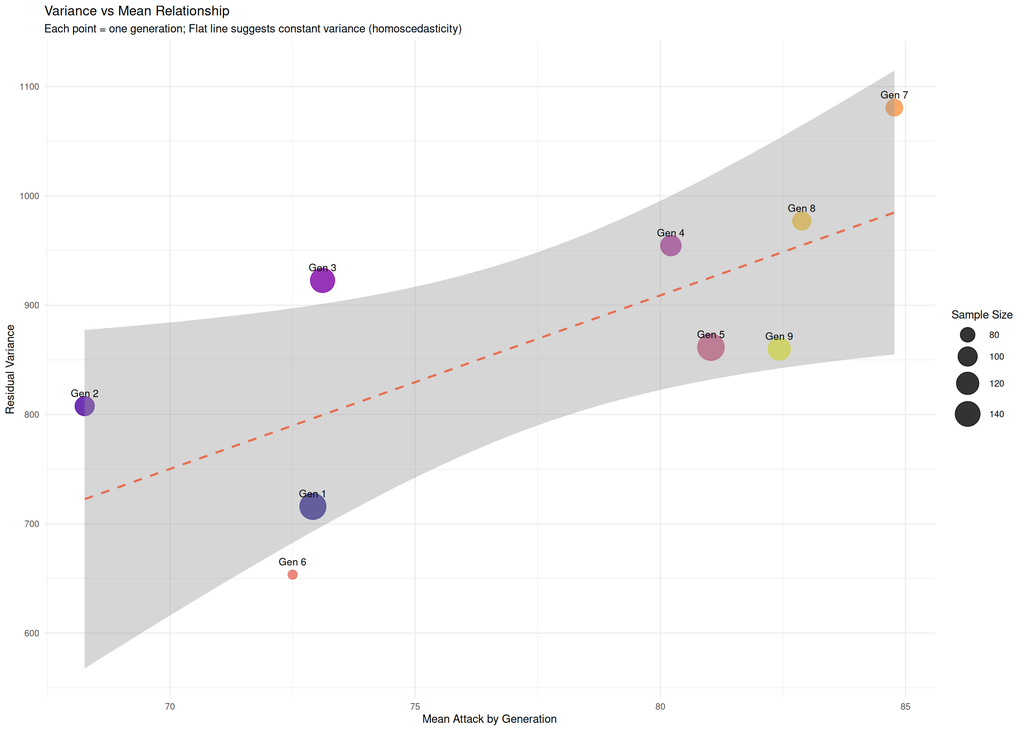

```r
# ═══════════════════════════════════════════════════════════════════
# VISUALIZATION 1: Variance vs Mean by Generation
# ═══════════════════════════════════════════════════════════════════
p1 <- ggplot(var_by_gen, aes(x = mean_attack, y = var_residuals)) +
  geom_point(aes(size = n, color = gen), alpha = 0.8) +
  geom_smooth(method = "lm", se = TRUE, color = "#E76F51", linetype = "dashed") +
  geom_text(aes(label = paste0("Gen ", gen)), vjust = -1.2, size = 3.5) +
  scale_size_continuous(range = c(4, 12), name = "Sample Size") +
  scale_color_viridis_d(option = "plasma", guide = "none") +
  labs(title = "Variance vs Mean Relationship",
       subtitle = "Each point = one generation; Flat line suggests constant variance (homoscedasticity)",
       x = "Mean Attack by Generation",
       y = "Residual Variance") +
  theme_minimal() +
  theme(legend.position = "right")

# ═══════════════════════════════════════════════════════════════════
# VISUALIZATION 2: Residual Boxplots by Generation
# ═══════════════════════════════════════════════════════════════════
pokemon_with_resid <- pokemon %>%
  mutate(residuals = residuals(model_simple))

p2 <- ggplot(pokemon_with_resid, aes(x = gen, y = residuals, fill = gen)) +
  geom_boxplot(alpha = 0.7, outlier.color = "#E76F51", outlier.size = 2) +
  geom_hline(yintercept = 0, linetype = "dashed", color = "red", linewidth = 1) +
  scale_fill_viridis_d(option = "plasma", guide = "none") +
  labs(title = "Residual Distribution by Generation",
       subtitle = "Similar box widths suggest homoscedasticity; Red line = zero",
       x = "Generation", y = "Residuals") +
  theme_minimal()

# ═══════════════════════════════════════════════════════════════════
# VISUALIZATION 3: SD Comparison Bar Chart
# ═══════════════════════════════════════════════════════════════════
overall_sd <- sd(pokemon$attack)
p3 <- ggplot(var_by_gen, aes(x = gen, y = sd_residuals, fill = gen)) +
  geom_bar(stat = "identity", alpha = 0.8, color = "white") +
  geom_hline(yintercept = mean(var_by_gen$sd_residuals), linetype = "dashed",
             color = "#E76F51", linewidth = 1.2) +
  geom_text(aes(label = round(sd_residuals, 1)), vjust = -0.5, size = 3.5) +
  scale_fill_viridis_d(option = "plasma", guide = "none") +
  labs(title = "Residual Standard Deviation by Generation",
       subtitle = paste0("Red line = average SD (", round(mean(var_by_gen$sd_residuals), 1),
                        "); Ratio max/min = ",
                        round(max(var_by_gen$sd_residuals)/min(var_by_gen$sd_residuals), 2)),
       x = "Generation", y = "Residual SD") +
  theme_minimal()

# ═══════════════════════════════════════════════════════════════════
# VISUALIZATION 4: Variance Ratio Assessment
# ═══════════════════════════════════════════════════════════════════
var_ratio <- max(var_by_gen$var_residuals) / min(var_by_gen$var_residuals)
sd_ratio <- max(var_by_gen$sd_residuals) / min(var_by_gen$sd_residuals)

assessment_df <- data.frame(
  Metric = c("Max Variance", "Min Variance", "Variance Ratio",
             "Max SD", "Min SD", "SD Ratio", "Assessment"),
  Value = c(round(max(var_by_gen$var_residuals), 1),
            round(min(var_by_gen$var_residuals), 1),
            round(var_ratio, 2),
            round(max(var_by_gen$sd_residuals), 1),
            round(min(var_by_gen$sd_residuals), 1),
            round(sd_ratio, 2),
            ifelse(sd_ratio < 2, "✓ Acceptable (ratio < 2)",
                   ifelse(sd_ratio < 3, "⚠ Borderline (ratio 2-3)",
                          "✗ Heteroscedastic (ratio > 3)")))
)

p4 <- ggplot(assessment_df, aes(x = Metric, y = 1)) +
  geom_tile(aes(fill = Metric == "Assessment"), color = "white", width = 0.9, height = 0.5) +
  geom_text(aes(label = Value), size = 4, fontface = "bold") +
  scale_fill_manual(values = c("TRUE" = "#2A9D8F", "FALSE" = "#E9C46A"), guide = "none") +
  coord_flip() +
  labs(title = "Variance Homogeneity Assessment",
       subtitle = "Rule of thumb: SD ratio < 2 indicates acceptable homoscedasticity") +
  theme_minimal() +
  theme(axis.text.x = element_blank(),
        axis.ticks = element_blank(),
        axis.title = element_blank(),
        panel.grid = element_blank())

# Display plots individually
print(p1)
```

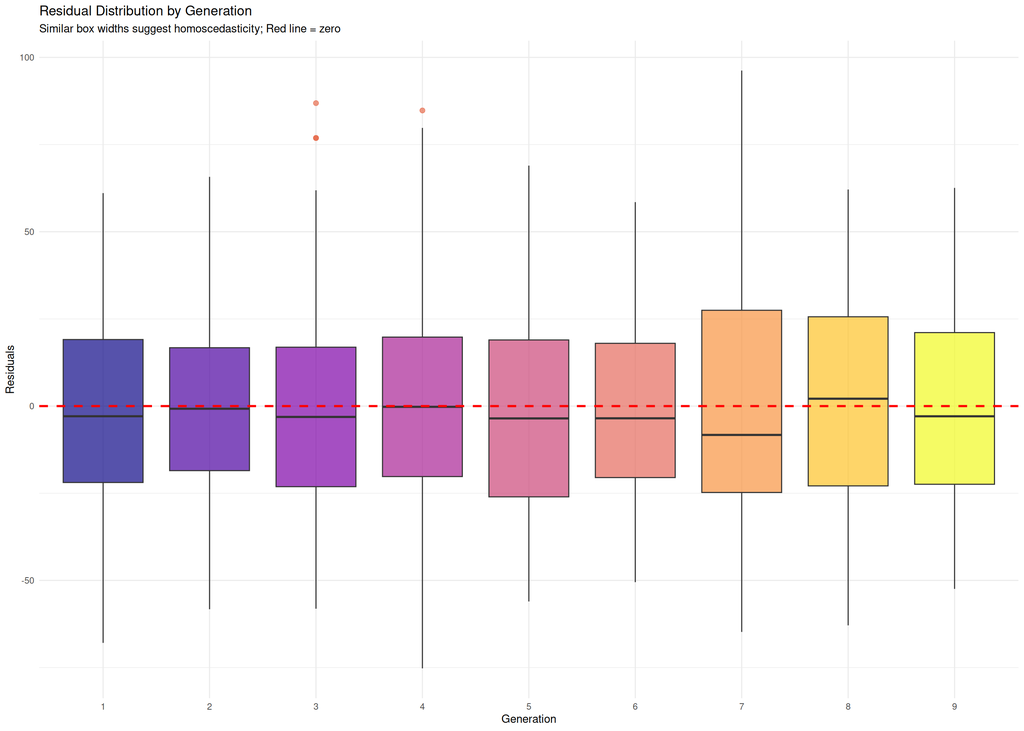

```r
print(p2)
```

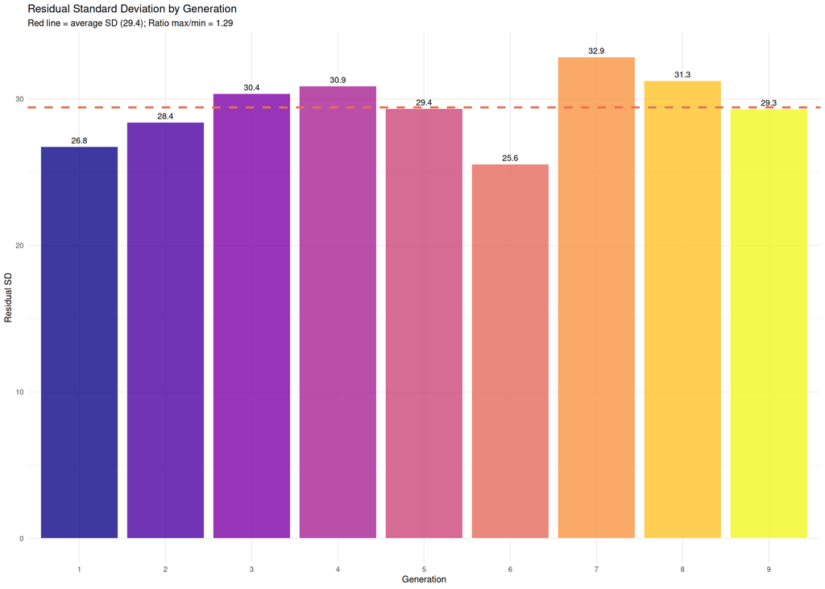

```r
print(p3)
```

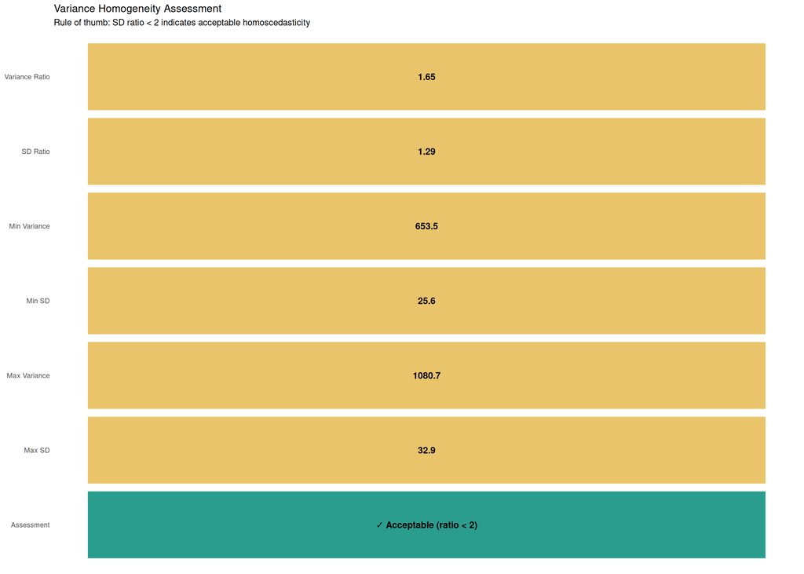

```r
print(p4)
```

**Interpretation:**

- **Gaussian GLM is appropriate if:** Variance is roughly constant across different mean values (flat relationship in Plot 1, similar box widths in Plot 2)
- **SD Ratio < 2:** Generally indicates acceptable homoscedasticity for regression
- If heteroscedasticity is detected, we can use robust standard errors or Gamma GLM as alternative

## 3.4 Breusch-Pagan Heteroscedasticity Test

```r
# Simple model
bp_simple <- bptest(model_simple)

# Full model with ALL available predictors
model_full <- lm(make_formula("attack", all_predictors), data = pokemon)
bp_full <- bptest(model_full)

bp_results <- data.frame(
  Model = c("Simple (attack ~ gen)", "Full (with controls)"),
  BP_Statistic = c(bp_simple$statistic, bp_full$statistic),
  p_value = c(bp_simple$p.value, bp_full$p.value),
  Result = c(
    ifelse(bp_simple$p.value > 0.05, "Homoscedastic", "Heteroscedastic"),
    ifelse(bp_full$p.value > 0.05, "Homoscedastic", "Heteroscedastic")
  )
)
bp_results[, 2:3] <- round(bp_results[, 2:3], 4)
print(bp_results, row.names = FALSE)
```

```
##                  Model BP_Statistic p_value          Result
##  Simple (attack ~ gen)      11.5534  0.1723   Homoscedastic
##   Full (with controls)     146.0423  0.0000 Heteroscedastic
```

### Full Model Variance Diagnostics

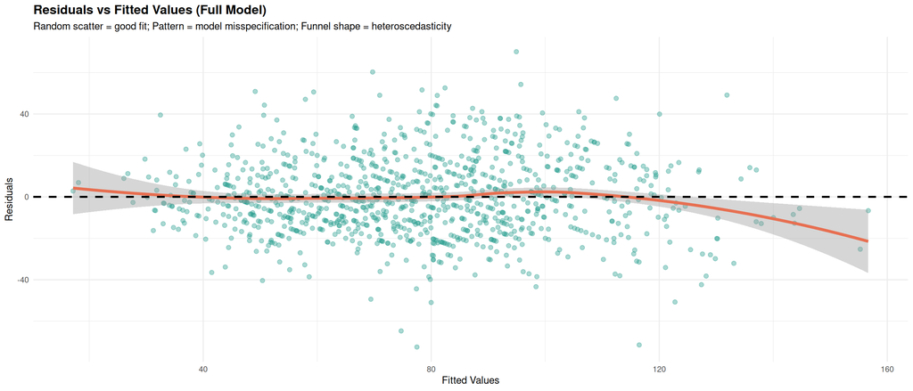

```r
# Get residuals and fitted values from full model
full_model_diag <- data.frame(
  fitted = fitted(model_full),
  residuals = residuals(model_full),
  std_resid = rstandard(model_full),
  sqrt_std_resid = sqrt(abs(rstandard(model_full)))
)

# ═══════════════════════════════════════════════════════════════════
# PLOT 1: Residuals vs Fitted (Full Model)
# ═══════════════════════════════════════════════════════════════════
p_resid_full <- ggplot(full_model_diag, aes(x = fitted, y = residuals)) +
  geom_point(alpha = 0.4, color = "#2A9D8F", size = 2) +
  geom_smooth(method = "loess", se = TRUE, color = "#E76F51", linewidth = 1.5) +
  geom_hline(yintercept = 0, linetype = "dashed", color = "black", linewidth = 1) +
  labs(title = "Residuals vs Fitted Values (Full Model)",
       subtitle = "Random scatter = good fit; Pattern = model misspecification; Funnel shape = heteroscedasticity",
       x = "Fitted Values", y = "Residuals") +
  theme_minimal() +
  theme(plot.title = element_text(size = 14, face = "bold"))

print(p_resid_full)
```

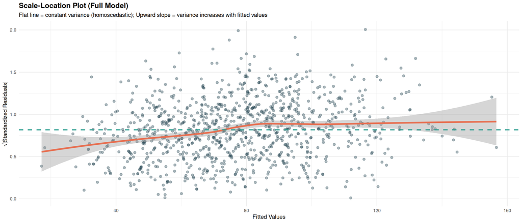

```r
# ═══════════════════════════════════════════════════════════════════
# PLOT 2: Scale-Location Plot (Full Model)
# ═══════════════════════════════════════════════════════════════════
p_scale_full <- ggplot(full_model_diag, aes(x = fitted, y = sqrt_std_resid)) +
  geom_point(alpha = 0.4, color = "#264653", size = 2) +
  geom_smooth(method = "loess", se = TRUE, color = "#E76F51", linewidth = 1.5) +
  geom_hline(yintercept = mean(full_model_diag$sqrt_std_resid),
             linetype = "dashed", color = "#2A9D8F", linewidth = 1) +
  labs(title = "Scale-Location Plot (Full Model)",
       subtitle = "Flat line = constant variance (homoscedastic); Upward slope = variance increases with fitted values",
       x = "Fitted Values", y = "√|Standardized Residuals|") +
  theme_minimal() +
  theme(plot.title = element_text(size = 14, face = "bold"))

print(p_scale_full)
```

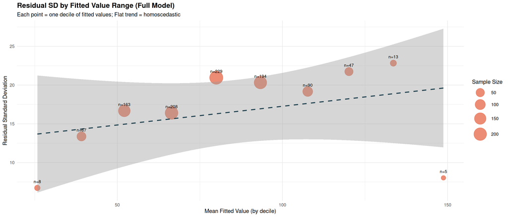

```r
# ═══════════════════════════════════════════════════════════════════
# PLOT 3: Variance by Fitted Value Bins (Full Model)
# ═══════════════════════════════════════════════════════════════════
# Create bins of fitted values
full_model_diag$fitted_bin <- cut(full_model_diag$fitted, breaks = 10, labels = FALSE)

var_by_bin <- full_model_diag %>%
  group_by(fitted_bin) %>%
  summarise(
    n = n(),
    mean_fitted = mean(fitted),
    var_residuals = var(residuals),
    sd_residuals = sd(residuals)
  ) %>%
  filter(!is.na(fitted_bin))

p_var_bins <- ggplot(var_by_bin, aes(x = mean_fitted, y = sd_residuals)) +
  geom_point(aes(size = n), color = "#E76F51", alpha = 0.8) +
  geom_smooth(method = "lm", se = TRUE, color = "#264653", linetype = "dashed") +
  geom_text(aes(label = paste0("n=", n)), vjust = -1.5, size = 3) +
  scale_size_continuous(range = c(4, 12), name = "Sample Size") +
  labs(title = "Residual SD by Fitted Value Range (Full Model)",
       subtitle = "Each point = one decile of fitted values; Flat trend = homoscedastic",
       x = "Mean Fitted Value (by decile)",
       y = "Residual Standard Deviation") +
  theme_minimal() +
  theme(plot.title = element_text(size = 14, face = "bold"),
        legend.position = "right")

print(p_var_bins)
```

[figure not shown]

```r
# ═══════════════════════════════════════════════════════════════════
# PLOT 4: Compare Simple vs Full Model Residual Spread
# ═══════════════════════════════════════════════════════════════════
comparison_data <- data.frame(
  Model = rep(c("Simple (attack ~ gen)", "Full (38 predictors)"),
              c(nrow(pokemon), nrow(pokemon))),
  Residuals = c(residuals(model_simple), residuals(model_full)),
  Fitted = c(fitted(model_simple), fitted(model_full))
)

p_compare <- ggplot(comparison_data, aes(x = Fitted, y = Residuals, color = Model)) +
  geom_point(alpha = 0.3, size = 1.5) +
  geom_smooth(method = "loess", se = FALSE, linewidth = 1.5) +
  geom_hline(yintercept = 0, linetype = "dashed", color = "black") +
  scale_color_manual(values = c("Simple (attack ~ gen)" = "#E9C46A",
                                "Full (38 predictors)" = "#2A9D8F")) +
  facet_wrap(~Model, scales = "free_x") +
  labs(title = "Residual Comparison: Simple vs Full Model",
       subtitle = paste0("Simple model SD = ", round(sd(residuals(model_simple)), 1),
                        " | Full model SD = ", round(sd(residuals(model_full)), 1),
                        " | Reduction = ", round((1 - sd(residuals(model_full))/sd(residuals(model_simple)))*100, 1), "%"),
       x = "Fitted Values", y = "Residuals") +
  theme_minimal() +
  theme(plot.title = element_text(size = 14, face = "bold"),
        legend.position = "none",
        strip.text = element_text(size = 12, face = "bold"))

print(p_compare)
```

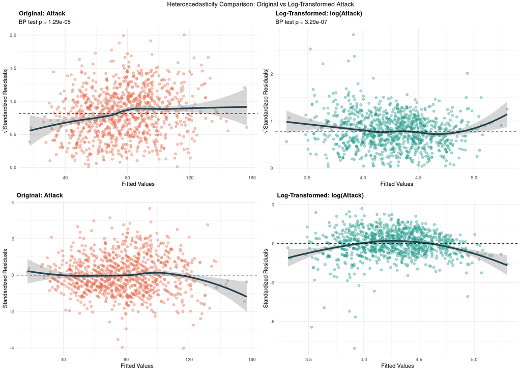

```r
# ═══════════════════════════════════════════════════════════════════
# LOG TRANSFORMATION CHECK: Does log(Attack) fix heteroscedasticity?
# ═══════════════════════════════════════════════════════════════════

# Fit model with log-transformed response
pokemon$log_attack <- log(pokemon$attack)
model_full_log <- lm(make_formula("log_attack", all_predictors), data = pokemon)

# Get diagnostics for log model
log_model_diag <- data.frame(
  fitted = fitted(model_full_log),
  residuals = residuals(model_full_log),
  std_resid = rstandard(model_full_log),
  sqrt_std_resid = sqrt(abs(rstandard(model_full_log)))
)

# Breusch-Pagan test for log model
bp_log <- bptest(model_full_log)

# ═══════════════════════════════════════════════════════════════════
# PLOT 1: Side-by-side Scale-Location comparison
# ═══════════════════════════════════════════════════════════════════
p_scale_original <- ggplot(full_model_diag, aes(x = fitted, y = sqrt_std_resid)) +
  geom_point(alpha = 0.4, color = "#E76F51", size = 2) +
  geom_smooth(method = "loess", se = TRUE, color = "#264653", linewidth = 1.5) +
  geom_hline(yintercept = mean(full_model_diag$sqrt_std_resid),
             linetype = "dashed", color = "black") +
  labs(title = "Original: Attack",
       subtitle = paste0("BP test p = ", format.pval(bp_full$p.value, digits = 3)),
       x = "Fitted Values", y = "√|Standardized Residuals|") +
  theme_minimal() +
  theme(plot.title = element_text(size = 12, face = "bold"))

p_scale_log <- ggplot(log_model_diag, aes(x = fitted, y = sqrt_std_resid)) +
  geom_point(alpha = 0.4, color = "#2A9D8F", size = 2) +
  geom_smooth(method = "loess", se = TRUE, color = "#264653", linewidth = 1.5) +
  geom_hline(yintercept = mean(log_model_diag$sqrt_std_resid),
             linetype = "dashed", color = "black") +
  labs(title = "Log-Transformed: log(Attack)",
       subtitle = paste0("BP test p = ", format.pval(bp_log$p.value, digits = 3)),
       x = "Fitted Values", y = "√|Standardized Residuals|") +
  theme_minimal() +
  theme(plot.title = element_text(size = 12, face = "bold"))

# ═══════════════════════════════════════════════════════════════════
# PLOT 2: Side-by-side Residuals vs Fitted
# ═══════════════════════════════════════════════════════════════════
p_resid_original <- ggplot(full_model_diag, aes(x = fitted, y = std_resid)) +
  geom_point(alpha = 0.4, color = "#E76F51", size = 2) +
  geom_smooth(method = "loess", se = TRUE, color = "#264653", linewidth = 1.5) +
  geom_hline(yintercept = 0, linetype = "dashed", color = "black") +
  labs(title = "Original: Attack",
       x = "Fitted Values", y = "Standardized Residuals") +
  theme_minimal() +
  theme(plot.title = element_text(size = 12, face = "bold"))

p_resid_log <- ggplot(log_model_diag, aes(x = fitted, y = std_resid)) +
  geom_point(alpha = 0.4, color = "#2A9D8F", size = 2) +
  geom_smooth(method = "loess", se = TRUE, color = "#264653", linewidth = 1.5) +
  geom_hline(yintercept = 0, linetype = "dashed", color = "black") +
  labs(title = "Log-Transformed: log(Attack)",
       x = "Fitted Values", y = "Standardized Residuals") +
  theme_minimal() +
  theme(plot.title = element_text(size = 12, face = "bold"))

# Combine plots
grid.arrange(
  p_scale_original, p_scale_log,
  p_resid_original, p_resid_log,
  ncol = 2,
  top = "Heteroscedasticity Comparison: Original vs Log-Transformed Attack"
)
```

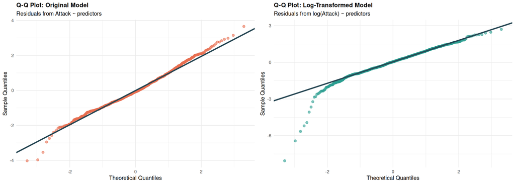

```r
# ═══════════════════════════════════════════════════════════════════
# Q-Q Plot Comparison
# ═══════════════════════════════════════════════════════════════════
p_qq_original <- ggplot(full_model_diag, aes(sample = std_resid)) +
  stat_qq(color = "#E76F51", alpha = 0.6, size = 2) +
  stat_qq_line(color = "#264653", linewidth = 1.2) +
  labs(title = "Q-Q Plot: Original Model",
       subtitle = "Residuals from Attack ~ predictors",
       x = "Theoretical Quantiles", y = "Sample Quantiles") +
  theme_minimal() +
  theme(plot.title = element_text(size = 12, face = "bold"))

p_qq_log <- ggplot(log_model_diag, aes(sample = std_resid)) +
  stat_qq(color = "#2A9D8F", alpha = 0.6, size = 2) +
  stat_qq_line(color = "#264653", linewidth = 1.2) +
  labs(title = "Q-Q Plot: Log-Transformed Model",
       subtitle = "Residuals from log(Attack) ~ predictors",
       x = "Theoretical Quantiles", y = "Sample Quantiles") +
  theme_minimal() +
  theme(plot.title = element_text(size = 12, face = "bold"))

grid.arrange(p_qq_original, p_qq_log, ncol = 2)
```

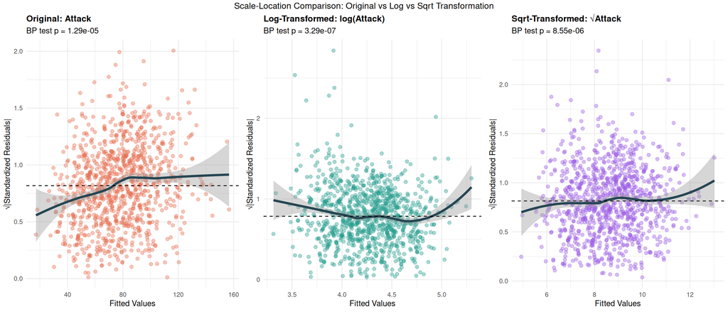

```r
# ═══════════════════════════════════════════════════════════════════
# SQRT TRANSFORMATION CHECK
# ═══════════════════════════════════════════════════════════════════

# Fit model with sqrt-transformed response
pokemon$sqrt_attack <- sqrt(pokemon$attack)
model_full_sqrt <- lm(make_formula("sqrt_attack", all_predictors), data = pokemon)

# Get diagnostics for sqrt model
sqrt_model_diag <- data.frame(
  fitted = fitted(model_full_sqrt),
  residuals = residuals(model_full_sqrt),
  std_resid = rstandard(model_full_sqrt),
  sqrt_std_resid = sqrt(abs(rstandard(model_full_sqrt)))
)

# Breusch-Pagan test for sqrt model
bp_sqrt <- bptest(model_full_sqrt)

# Scale-Location plots for all three
p_scale_sqrt <- ggplot(sqrt_model_diag, aes(x = fitted, y = sqrt_std_resid)) +
  geom_point(alpha = 0.4, color = "#9B5DE5", size = 2) +
  geom_smooth(method = "loess", se = TRUE, color = "#264653", linewidth = 1.5) +
  geom_hline(yintercept = mean(sqrt_model_diag$sqrt_std_resid),
             linetype = "dashed", color = "black") +
  labs(title = "Sqrt-Transformed: √Attack",
       subtitle = paste0("BP test p = ", format.pval(bp_sqrt$p.value, digits = 3)),
       x = "Fitted Values", y = "√|Standardized Residuals|") +
  theme_minimal() +
  theme(plot.title = element_text(size = 12, face = "bold"))

# Compare all three scale-location plots
grid.arrange(
  p_scale_original, p_scale_log, p_scale_sqrt,
  ncol = 3,
  top = "Scale-Location Comparison: Original vs Log vs Sqrt Transformation"
)
```

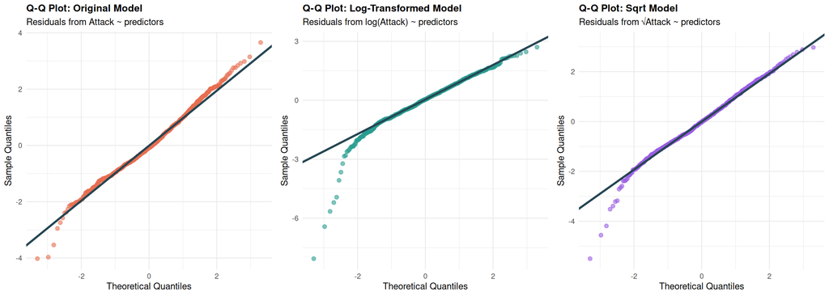

```r
# ═══════════════════════════════════════════════════════════════════
# Q-Q Plots for all three transformations
# ═══════════════════════════════════════════════════════════════════
p_qq_sqrt <- ggplot(sqrt_model_diag, aes(sample = std_resid)) +
  stat_qq(color = "#9B5DE5", alpha = 0.6, size = 2) +
  stat_qq_line(color = "#264653", linewidth = 1.2) +
  labs(title = "Q-Q Plot: Sqrt Model",
       subtitle = "Residuals from √Attack ~ predictors",
       x = "Theoretical Quantiles", y = "Sample Quantiles") +
  theme_minimal() +
  theme(plot.title = element_text(size = 12, face = "bold"))

grid.arrange(p_qq_original, p_qq_log, p_qq_sqrt, ncol = 3)
```

```r
# ═══════════════════════════════════════════════════════════════════
# COMPREHENSIVE SUMMARY: All Transformations
# ═══════════════════════════════════════════════════════════════════
cat(paste0(
  "\n═══════════════════════════════════════════════════════════════════\n",
  "         TRANSFORMATION COMPARISON SUMMARY\n",
  "═══════════════════════════════════════════════════════════════════\n\n"
))
```

```
##
## ═══════════════════════════════════════════════════════════════════
##          TRANSFORMATION COMPARISON SUMMARY
## ═══════════════════════════════════════════════════════════════════
```

```r
comparison_table <- data.frame(
  Metric = c("Response Variable", "BP Statistic", "BP p-value",
             "Heteroscedastic?", "Residual SD", "R²"),
  Original = c(
    "Attack",
    round(bp_full$statistic, 2),
    format.pval(bp_full$p.value, digits = 4),
    ifelse(bp_full$p.value < 0.05, "Yes ⚠", "No ✓"),
    round(sd(residuals(model_full)), 3),
    round(summary(model_full)$r.squared, 4)
  ),
  Log = c(
    "log(Attack)",
    round(bp_log$statistic, 2),
    format.pval(bp_log$p.value, digits = 4),
    ifelse(bp_log$p.value < 0.05, "Yes ⚠", "No ✓"),
    round(sd(residuals(model_full_log)), 4),
    round(summary(model_full_log)$r.squared, 4)
  ),
  Sqrt = c(
    "√Attack",
    round(bp_sqrt$statistic, 2),
    format.pval(bp_sqrt$p.value, digits = 4),
    ifelse(bp_sqrt$p.value < 0.05, "Yes ⚠", "No ✓"),
    round(sd(residuals(model_full_sqrt)), 4),
    round(summary(model_full_sqrt)$r.squared, 4)
  )
)
print(comparison_table, row.names = FALSE)
```

```
##             Metric  Original         Log      Sqrt
##  Response Variable    Attack log(Attack)   √Attack
##       BP Statistic    146.04      160.79    147.75
##         BP p-value 1.285e-05   3.286e-07 8.551e-06
##   Heteroscedastic?     Yes ⚠       Yes ⚠     Yes ⚠
##        Residual SD    18.742      0.2936    1.1065
##                 R²    0.6049      0.5666    0.6019
```

```r
# Determine best transformation
p_values <- c(Original = bp_full$p.value, Log = bp_log$p.value, Sqrt = bp_sqrt$p.value)
best_transform <- names(which.max(p_values))

if(max(p_values) > 0.05) {
  rec_text <- paste0(
    "✓ The ", best_transform, " transformation achieves HOMOSCEDASTICITY (p > 0.05)\n",
    "  → Recommended for valid standard errors\n"
  )
} else {
  rec_text <- paste0(
    "⚠ None of the transformations fully resolve heteroscedasticity\n",
    "  → Consider using:\n",
    "    1. Robust/sandwich standard errors\n",
    "    2. Gamma GLM with log link\n",
    "    3. Weighted least squares\n"
  )
}

cat(paste0(
  "\n═══════════════════════════════════════════════════════════════════\n",
  "                    RECOMMENDATION\n",
  "═══════════════════════════════════════════════════════════════════\n\n",
  "BP p-values (higher = more homoscedastic):\n",
  "  Original:  ", format.pval(bp_full$p.value, digits = 4), "\n",
  "  Log:       ", format.pval(bp_log$p.value, digits = 4), "\n",
  "  Sqrt:      ", format.pval(bp_sqrt$p.value, digits = 4), "\n\n",
  "Best transformation: ", best_transform, "\n",
  "  (Highest BP p-value = least heteroscedasticity)\n\n",
  rec_text, "\n",
  "--- Coefficient Interpretation ---\n",
  "Original: β = change in Attack points\n",
  "Log:      β ≈ % change in Attack (multiply by 100)\n",
  "Sqrt:     β = change in √Attack units (harder to interpret)\n"
))
```

```
##
## ═══════════════════════════════════════════════════════════════════
##                     RECOMMENDATION
## ═══════════════════════════════════════════════════════════════════
##
## BP p-values (higher = more homoscedastic):
##   Original:  1.285e-05
##   Log:       3.286e-07
##   Sqrt:      8.551e-06
##
## Best transformation: Original.BP
##   (Highest BP p-value = least heteroscedasticity)
##
## ⚠ None of the transformations fully resolve heteroscedasticity
##   → Consider using:
##     1. Robust/sandwich standard errors
##     2. Gamma GLM with log link
##     3. Weighted least squares
##
## --- Coefficient Interpretation ---
## Original: β = change in Attack points
## Log:      β ≈ % change in Attack (multiply by 100)
## Sqrt:     β = change in √Attack units (harder to interpret)
```

```r
# Summary assessment
sd_ratio_full <- max(var_by_bin$sd_residuals) / min(var_by_bin$sd_residuals)

if(bp_full$p.value < 0.05) {
  rec_hetero <- paste0(
    "Recommendation:\n",
    "  The full model shows heteroscedasticity. Consider:\n",
    "  1. Using robust standard errors (sandwich estimator)\n",
    "  2. Gamma GLM as alternative (already included as robustness check)\n",
    "  3. Results remain valid for coefficient estimates, but SEs may be affected\n"
  )
} else {
  rec_hetero <- paste0(
    "Recommendation:\n",
    "  The full model shows acceptable homoscedasticity.\n",
    "  Standard GLM inference is valid.\n"
  )
}

cat(paste0(
  "\n═══════════════════════════════════════════════════════════════════\n",
  "                 HETEROSCEDASTICITY ASSESSMENT\n",
  "═══════════════════════════════════════════════════════════════════\n\n",
  "Breusch-Pagan Test Results:\n",
  "  Simple model: p = ", round(bp_simple$p.value, 4), " ",
    ifelse(bp_simple$p.value > 0.05, "→ Homoscedastic ✓", "→ Heteroscedastic ⚠"), "\n",
  "  Full model:   p = ", round(bp_full$p.value, 4), " ",
    ifelse(bp_full$p.value > 0.05, "→ Homoscedastic ✓", "→ Heteroscedastic ⚠"), "\n\n",
  "Full Model Variance Check:\n",
  "  SD Range: ", round(min(var_by_bin$sd_residuals), 1), " - ",
    round(max(var_by_bin$sd_residuals), 1), "\n",
  "  SD Ratio (max/min): ", round(sd_ratio_full, 2), "\n",
  "  Assessment: ", ifelse(sd_ratio_full < 2, "Acceptable (ratio < 2) ✓",
                            ifelse(sd_ratio_full < 3, "Borderline (ratio 2-3) ⚠",
                                   "Problematic (ratio > 3) ✗")), "\n\n",
  rec_hetero
))
```

```
##
## ═══════════════════════════════════════════════════════════════════
##                  HETEROSCEDASTICITY ASSESSMENT
## ═══════════════════════════════════════════════════════════════════
##
## Breusch-Pagan Test Results:
##   Simple model: p = 0.1723 → Homoscedastic ✓
##   Full model:   p = 0 → Heteroscedastic ⚠
##
## Full Model Variance Check:
##   SD Range: 6.7 - 22.8
##   SD Ratio (max/min): 3.39
##   Assessment: Problematic (ratio > 3) ✗
##
## Recommendation:
##   The full model shows heteroscedasticity. Consider:
##   1. Using robust standard errors (sandwich estimator)
##   2. Gamma GLM as alternative (already included as robustness check)
##   3. Results remain valid for coefficient estimates, but SEs may be affected
```

## 3.5 Multicollinearity Check (VIF)

```r
# VIF for full model
vif_values <- car::vif(model_full)

if(is.matrix(vif_values)) {
  vif_df <- data.frame(
    Variable = rownames(vif_values),
    GVIF = round(vif_values[, 1], 2),
    Df = vif_values[, 2],
    `GVIF_adj` = round(vif_values[, 3], 2)
  )
  print(vif_df, row.names = FALSE)
  max_vif <- max(vif_values[, 3])
} else {
  vif_df <- data.frame(Variable = names(vif_values), VIF = round(vif_values, 2))
  print(vif_df, row.names = FALSE)
  max_vif <- max(vif_values)
}
```

```
##            Variable         GVIF Df GVIF_adj
##                 gen 4.980000e+00  8     1.11
##                  hp 2.090000e+00  1     1.45
##             defense 2.410000e+00  1     1.55
##           sp_attack 2.440000e+00  1     1.56
##          sp_defense 2.130000e+00  1     1.46
##               speed 1.830000e+00  1     1.35
##        capture_rate 2.580000e+00  1     1.61
##              rarity 5.900000e+00  3     1.34
##            height_m 2.180000e+00  1     1.48
##           weight_kg 2.600000e+00  1     1.61
##      base_egg_steps 5.000000e+00  1     2.24
##       num_abilities 1.780000e+00  1     1.33
##          evo_length 1.610000e+00  1     1.27
##  has_mega_evolution 1.410000e+00  1     1.19
##      has_gigantamax 1.240000e+00  1     1.11
##       class_primary 1.062509e+15 17     2.77
##     class_secondary 1.618339e+12 18     2.18
##        percent_male 2.060000e+00  1     1.44
##      percent_female 1.990000e+00  1     1.41
##         votes_first 9.060000e+00  1     3.01
##         votes_top_6 9.830000e+00  1     3.14
##      against_normal 1.009000e+02  1    10.04
##        against_fire 1.641000e+01  1     4.05
##       against_water 1.408000e+01  1     3.75
##    against_electric 1.539000e+01  1     3.92
##       against_grass 1.384000e+01  1     3.72
##         against_ice 1.452000e+01  1     3.81
##    against_fighting 1.159000e+01  1     3.40
##      against_poison 1.753000e+01  1     4.19
##      against_ground 1.209000e+01  1     3.48
##      against_flying 2.115000e+01  1     4.60
##    against_psychict 1.404000e+01  1     3.75
##         against_bug 9.390000e+00  1     3.06
##        against_rock 1.751000e+01  1     4.18
##       against_ghost 4.795000e+01  1     6.92
##      against_dragon 8.152000e+01  1     9.03
##        against_dark 3.258000e+01  1     5.71
##       against_steel 1.847000e+01  1     4.30
##       against_fairy 1.547000e+01  1     3.93
```

## 3.6 Link Function Selection

The link function connects the linear predictor to the expected value of the response.

```r
# Compare identity vs log link predictions
model_identity <- glm(attack ~ gen + hp + defense, data = pokemon,
                      family = gaussian(link = "identity"))
model_log <- glm(attack ~ gen + hp + defense, data = pokemon,
                 family = gaussian(link = "log"))

# Prediction comparison
link_comparison <- data.frame(
  Actual = pokemon$attack,
  Identity_Pred = fitted(model_identity),
  Log_Pred = fitted(model_log)
)

rmse_identity <- sqrt(mean((link_comparison$Actual - link_comparison$Identity_Pred)^2))
rmse_log <- sqrt(mean((link_comparison$Actual - link_comparison$Log_Pred)^2))

link_choice <- data.frame(
  Link = c("Identity", "Log"),
  Formula = c("E(Y) = Xβ", "log(E(Y)) = Xβ"),
  RMSE = c(round(rmse_identity, 2), round(rmse_log, 2)),
  Interpretation = c("β = change in Attack points", "exp(β) = multiplicative change")
)
print(link_choice, row.names = FALSE)
```

```
##      Link        Formula  RMSE                 Interpretation
##  Identity      E(Y) = Xβ 23.87    β = change in Attack points
##       Log log(E(Y)) = Xβ 24.31 exp(β) = multiplicative change
```

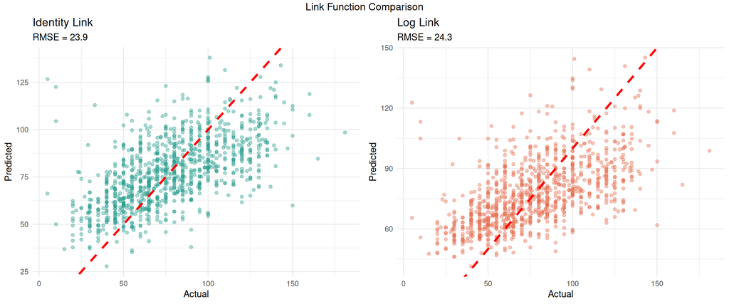

```r
# Visual comparison
p_id <- ggplot(link_comparison, aes(x = Actual, y = Identity_Pred)) +
  geom_point(alpha = 0.4, color = "#2A9D8F") +
  geom_abline(slope = 1, intercept = 0, color = "red", linewidth = 1.2, linetype = "dashed") +
  labs(title = "Identity Link", subtitle = paste0("RMSE = ", round(rmse_identity, 1)),
       x = "Actual", y = "Predicted") +
  theme_minimal()

p_log <- ggplot(link_comparison, aes(x = Actual, y = Log_Pred)) +
  geom_point(alpha = 0.4, color = "#E76F51") +
  geom_abline(slope = 1, intercept = 0, color = "red", linewidth = 1.2, linetype = "dashed") +
  labs(title = "Log Link", subtitle = paste0("RMSE = ", round(rmse_log, 1)),
       x = "Actual", y = "Predicted") +
  theme_minimal()

grid.arrange(p_id, p_log, ncol = 2, top = "Link Function Comparison")
```